# Principles of Statistical Data Analysis

Home Work 1

Jiacheng Shen

Sajjad Ayashm

2024-10-28

# 1 Question 1: Data Exploration

Table 1.1: Data in ants.RData file

| abundance | moisture |
| --- | --- |
| 2 | 20.0 |
| 226 | 17.6 |
| 52 | 12.2 |
| 37 | 15.6 |
| 0 | 20.5 |
| 255 | 20.5 |

## 1.1 Data Summary:

Table 1.2: Summary of Abundance of Ants and Moisture of Soil

|  | Min. | 1st Qu. | Median | Mean | 3rd Qu. | Max. |
| --- | --- | --- | --- | --- | --- | --- |
| Abundance | 0.00 | 6.75 | 35.50 | 86.31 | 99.25 | 767.00 |
| Moisture | 12.0 | 15.4 | 17.9 | 17.5 | 19.9 | 21.5 |

Additionally, the variance of ant abundance in the sample is **1.99e+04**, and for moisture, it is **7.083**

## 1.2 Data Visualization

We visualized the distribution of ant abundance using a histogram (Figure 1.1) and boxplot (Figure 1.2) to identify its spread and any potential outliers. A scatter plot of soil moisture versus ant abundance (Figure 1.3) was created to explore their relationship. Additionally, a mean-variance plot (Figure 1.4) was used to assess overdispersion, which supports the choice of a negative binomial model for this data.

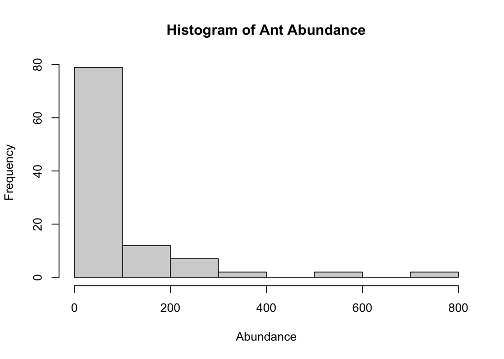

Figure 1.1: Histogram of Ant Abundance

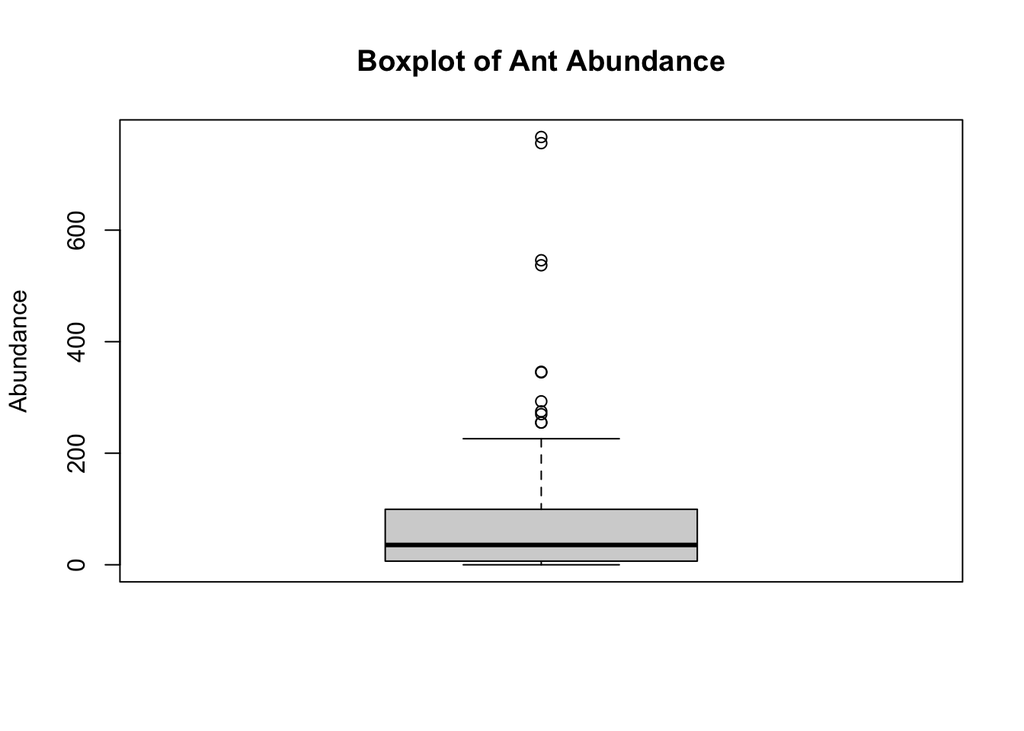

Figure 1.2: Boxplot of Abundance

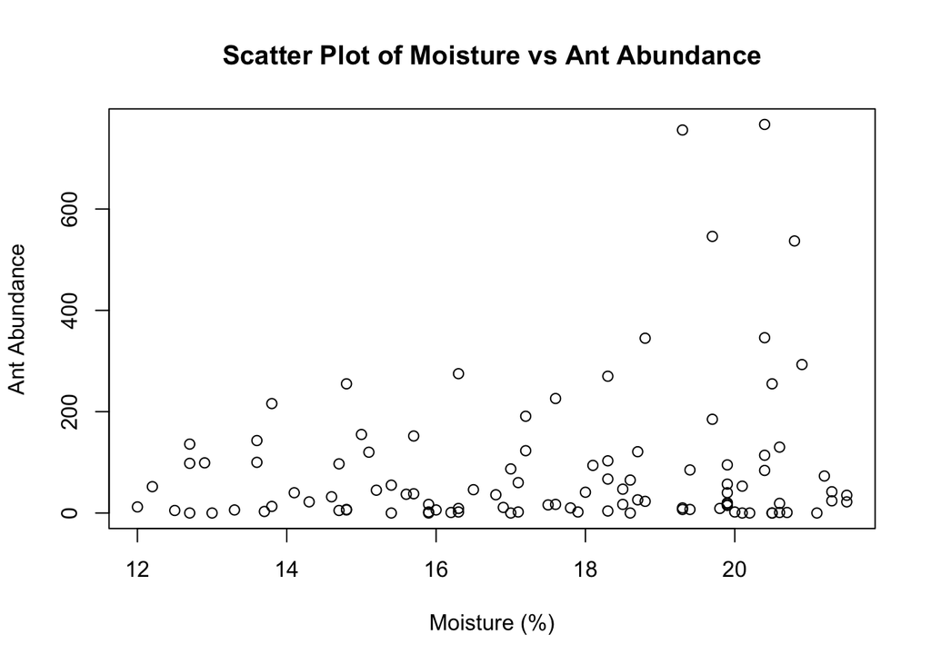

Figure 1.3: Scatter Plot of Moisture vs Ant Abundance

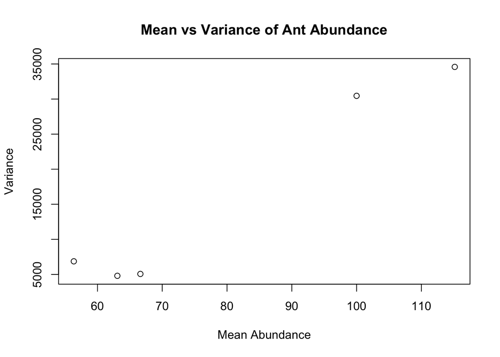

Figure 1.4: Mean vs Variance of Ant Abundance

# 2 Question 2: Likelihood Function

The likelihood function is shown in Equation.

$$L(\beta_0, \beta_1, \phi) = \prod_{i=1}^n \frac{\Gamma(y_i + 1 / \phi)}{\Gamma(1 / \phi) \, y_i!} \left( \frac{1}{1 + \mu_i \phi} \right)^{1 / \phi} \left( \frac{\mu_i \phi}{1 + \mu_i \phi} \right)^{y_i}$$

## 2.1 Likelihood Function

To define the likelihood function in R, we use a function that computes the product of probabilities for all observations.

```r
# Define the likelihood function
likelihood_function <- function(params, abundance, moisture) {
  beta_0 <- params[1]  # The intercept parameter
  beta_1 <- params[2]  # The coefficient for moisture
  phi <- params[3]     # The overdispersion parameter

  # Calculate the mean (mu) for each observation
  mu <- exp(beta_0 + beta_1 * moisture)

  # Compute the negative binomial likelihood for each observation
  likelihoods <- dnbinom(abundance, size = 1/phi, mu = mu, log = FALSE)

  # Calculate the total likelihood by multiplying individual likelihoods
  total_likelihood <- prod(likelihoods)

  return(total_likelihood)
}

initial_params <- c(1, 0.1, 0.5)  # Example starting values for beta_0, beta_1, and phi
likelihood_value <- likelihood_function(initial_params, ants$abundance, ants$moisture)
```

**Note:** If we use the set of parameters described in the example above, the likelihood value results 0. One possible reason is that the number is too small to exhibit. That’s why we derive the following log likelihood function.

## 2.2 Log-Likelihood Function

The log-likelihood function computes the sum of the log-probabilities instead of multiplying the probabilities directly, providing more numerical stability.

```r
# Define the log-likelihood function
log_likelihood <- function(params, abundance, moisture) {
  beta_0 <- params[1]  # The intercept parameter
  beta_1 <- params[2]  # The coefficient for moisture
  phi <- params[3]     # The overdispersion parameter

  # Calculate the mean (mu) for each observation
  mu <- exp(beta_0 + beta_1 * moisture)

  # Compute the log-likelihood for each observation
  log_lik <- sum(
    lgamma(abundance + 1 / phi) - lgamma(1 / phi) - lgamma(abundance + 1) +
    (1 / phi) * log(1 / (1 + mu * phi)) +
    abundance * log(mu * phi / (1 + mu * phi))
  )

  return(log_lik)  # Return the log-likelihood
}

initial_params <- c(1, 0.1, 0.5)  # Example starting values for beta_0, beta_1, and phi
log_likelihood_value <- log_likelihood(initial_params, ants$abundance, ants$moisture)
```

Using the same set of parameters, the log likelihood values result -1148.303, which makes more sense.

**Explanation:** Likelihood vs. Log-Likelihood: The likelihood function directly computes the product of individual probabilities, which can lead to underflow when dealing with very small values. The log-likelihood function sums the logarithms of the probabilities, providing greater numerical stability.

# 3 Question 3: Estimating Equation for $\beta_1$

Our objective is to derive the estimating equation for $\beta_1$ by maximizing the log-likelihood function. The maximum likelihood estimate (MLE) for $\beta_1$ can be obtained by setting the derivative of the log-likelihood with respect to $\beta_1$ to zero, which requires numerical optimization.

The log-likelihood function is given by:

$$\ell(\beta_0, \beta_1, \phi) = \sum_{i=1}^n \left[ \log \left( \Gamma(y_i + \frac{1}{\phi}) \right) - \log \left( \Gamma(\frac{1}{\phi}) \right) - \log(y_i!) + \frac{1}{\phi} \log \left( \frac{1}{1 + \exp(\beta_0 + \beta_1 x_i) \phi} \right) + y_i \log \left( \frac{\exp(\beta_0 + \beta_1 x_i) \phi}{1 + \exp(\beta_0 + \beta_1 x_i) \phi} \right) \right]$$

To find the estimating equation for $\beta_1$, we differentiate this log-likelihood with respect to $\beta_1$:

$$\ell(\beta_1) = \sum_{i=1}^n \left[ \frac{1}{\phi} \log \left( \frac{1}{1 + \exp(\beta_0 + \beta_1 x_i) \phi} \right) + y_i \log \left( \frac{\exp(\beta_0 + \beta_1 x_i) \phi}{1 + \exp(\beta_0 + \beta_1 x_i) \phi} \right) \right]$$

Differentiating both terms with respect to $\beta_1$ yields:
$$\frac{\partial \ell(\beta_1)}{\partial \beta_1} = \sum_{i=1}^n \left[ \frac{x_i \left( y_i - \exp(\beta_0 + \beta_1 x_i) \right)}{1 + \exp(\beta_0 + \beta_1 x_i) \phi} \right]$$

Setting this result equal to zero gives the estimating equation:

$$\sum_{i=1}^n \left[ \frac{x_i \left( y_i - \exp(\beta_0 + \beta_1 x_i) \right)}{1 + \exp(\beta_0 + \beta_1 x_i) \phi} \right] = 0$$

## 3.1 Step 1: Negative Log-Likelihood Function

Since the `optim()` function in R minimizes functions, we use the negative log-likelihood function for the optimization process. The negative log-likelihood is simply the negative of the log-likelihood function.

```r
# Define the negative log-likelihood function for optimization
neg_log_likelihood <- function(params) {
  -log_likelihood(params, ants$abundance, ants$moisture)
}
```

## 3.2 Step 2: Perform Optimization to Estimate Parameters

We now use the `optim()` function to find the maximum likelihood estimates (MLE) for $\beta_0$, $\beta_1$, and $\phi$. The initial guesses for the parameters are provided, and the optimization is performed using the BFGS method.

```r
# Initial parameter guesses: beta_0 = 1, beta_1 = 0.1, phi = 0.5
initial_params <- c(1, 0.1, 0.5)

# Perform optimization to estimate beta_0, beta_1, and phi
optim_result <- optim(initial_params, neg_log_likelihood, method = "BFGS")
# Extract the estimated parameters
estimated_params <- optim_result$par

# Assign the estimates to beta_0_hat, beta_1_hat, and phi_hat
beta_0_hat <- estimated_params[1]
beta_1_hat <- estimated_params[2]
phi_hat <- estimated_params[3]
```

# 4 Question 4: Log-Likelihood Optimization with Respect to $\beta_1$

In this question, we explore the relationship between $\beta_1$ and the log-likelihood function, given the parameter estimates for $\beta_0$ and $\phi$. Our objective is to visualize how changes in $\beta_1$ affect the log-likelihood, helping us understand its influence on the model.

```r
# Given values
beta0 <- 2.509067
phi <- 2.289377
x_data <- ants$moisture  # Observed soil moisture data
y_data <- ants$abundance  # Observed ant abundance data

# Define the log-likelihood function in terms of beta1
log_likelihood <- function(beta1) {
  mu <- exp(beta0 + beta1 * x_data)
  sum(dnbinom(y_data, size = 1/phi, mu = mu, log = TRUE))
}

# Define a range of beta1 values
beta1_values <- seq(-5, 5, length.out = 100)

# Compute the log-likelihood for each beta1 value
log_likelihood_values <- sapply(beta1_values, log_likelihood)
```

In the Figure 4.1 above, we observe the log-likelihood values across a range of $\beta_1$ values. The peak of this curve indicates the value of that maximizes the log-likelihood, corresponding to the most likely estimate of$\beta_1$ given the data. This visualization aids in understanding how sensitive the model’s fit is to changes in $\beta_1$.

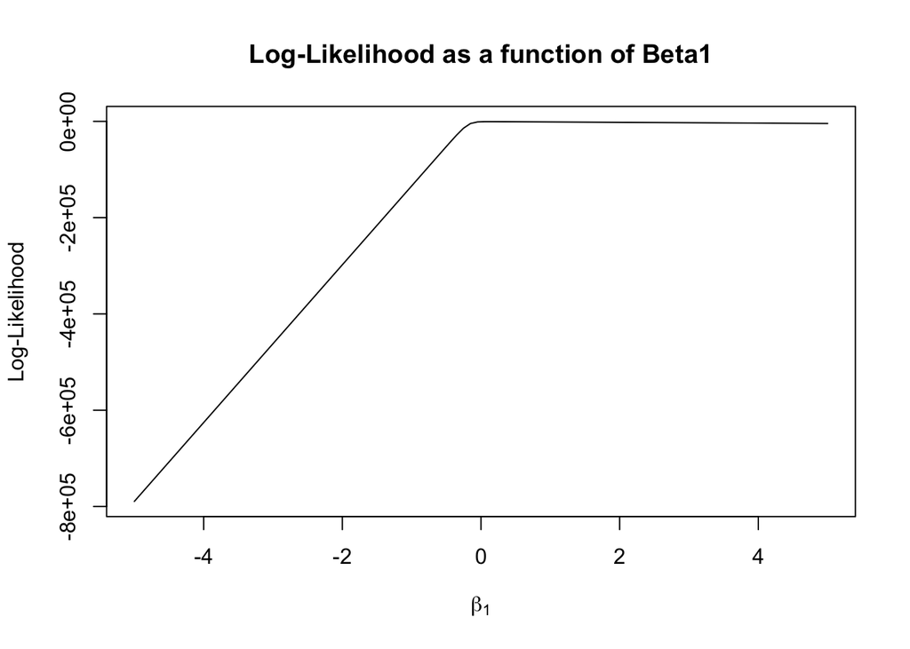

Figure 4.1: Log likelihood as a function of beta 1

```r
# Plot the log-likelihood function
plot(beta1_values, log_likelihood_values, type = "l",
     xlab = expression(beta[1]),
     ylab = "Log-Likelihood",
     main = "Log-Likelihood as a function of Beta1")
```

# 5 Question 5: Estimating the Optimal Value of $\beta_1$

To estimate the optimal value of $\beta_1$ that maximizes the log-likelihood, we use the `optim()` function in R with the BFGS optimization method:

```r
# Optimize to find beta1
result <- optim(par = 0, fn = log_likelihood, control = list(fnscale = -1), method = "BFGS")

# Extract the estimated beta1
beta1_estimate <- result$par
```

The estimated value of $\beta_1$ is 0.109, which provides the most likely parameter value based on the observed data and model assumptions.

# 6 Question 6: Evaluating the Estimating Equation at $\beta_1$

To verify the estimated $\beta_1$ value from Question 5, we compute the estimating equation at $\beta_1$ to see if it approximates zero, as expected for a maximum likelihood estimate.

```r
# Define the estimating equation function
estimating_equation <- function(beta1, beta0, phi, x, y) {
  sum(x * (y - exp(beta0 + beta1 * x)) / (1 + exp(beta0 + beta1 * x) * phi))
}

# Calculate the value of the estimating equation at beta1_estimate
result <- estimating_equation(beta1_estimate, beta0, phi, x_data, y_data)
```

The resulting value of the estimating equation is **-0.017**. A result close to zero suggests that $\beta_1$ is indeed an optimal estimate, indicating that the observed data align well with the expected values under the model.